# 04.05.02.00.RelatividadEspecial.CinematicaRelativista.AceleracionPropiaConstante

Indice | Previo: RelatividadEspecial.CinematicaRelativista.Definiciones | Siguiente: RelatividadEspecial.DinamicaRelativista.EnergiaMomentum

### 4.11.3. Movimiento con cuadriaceleración constante

En un movimiento en el cuál tanto la velocidad como la aceleración dependen del tiempo $\vec{v}(t)$ y $\vec{a}(t)$, siempre es posible encontrar un sistema de referencia inercial que se mueve instantáneamente con velocidad $\vec{v}(t)$ tal que la aceleración del cuerpo es la aceleración propia.

Podemos modelar lo que pasa a una partícula que se mueve de una manera tal que su aceleración propia $\alpha_L$ es constante. En este caso se cumple que:

$$ (A_L^0)^2-(A_L^x)^2 = \alpha_L^2 $$

Para saber cuánto valen las componentes de la cuadriaceleración en un momento dado pormos escribir su relación con las componentes de cuadrivelocidad:

$$ A^0_L U^0_L-A^x_L U^x_L=0 $$

Por otro lado las componentes de la cuadrivelocidad satisfacen:

$$ (U_L^0)^2-(U_L^x)^2 = 1 $$

Eliminando obtenemos las ecuaciones:

\begin{eqnarray} \nonumber A_L^0 & = & \alpha_L U_L^x \\ \nonumber A_L^x & = & \alpha_L U_L^0 \\ \end{eqnarray}

Si derivamos la segunda ecuación respecto del tiempo propio, obtenemos:

$$ \frac{\mathrm{d}A_L^x}{\mathrm{d}\tau}=\alpha_L A_L^0 = \alpha_L^2 U_L^x $$

donde hemos usado primero el hecho que $\mathrm{d}U_L^0/\mathrm{d}\tau=A_L^0$ y luego la primera ecuación. Esta ecuación se puede escribir como:

$$ \frac{\mathrm{d}^2 U_L^x}{\mathrm{d}\tau^2}=\alpha_L^2 U_L^x $$

Que tiene como solución general:

$$ U_L^x = A \exp(\alpha_L \tau) + B \exp(-\alpha_L \tau) $$

Asumiendo que $U_L^x(0)=0$ y $\mathrm{d}U_L^x(0)/\mathrm{d}\tau=\alpha_L$ obtenemos la solución para la componente $x$ de la cuadrivelocidad:

$$ U_L^x = \sinh(\alpha_L\tau) $$

Si reconocemos que $U_L^x=\gamma v_{Lx}$ y despejamos la velocidad obtenemos:

$$ v_{Lx}=\tanh(\alpha_L \tau) $$

Si integramos ahora $U_L^x$ obtenemos para $x_L$:

$$ x_L(\tau)=\frac{1}{\alpha_L}\cosh(\alpha_L \tau) + k $$

donde $k$ es una constante. Adumiendo que $x_L(0)=0$ la solución para la posición es:

$$ x_L(\tau)=\frac{1}{\alpha_L}[\cosh(\alpha_L \tau) -1] $$

Queda un problema por resolver. Estamos describiendo el movimiento de la partícula en el sistema de referencia del observador donde el tiempo es $t$. ¿Cómo se relacionan $t$ con $\tau$?. Nos olvidamos que hay una ecuación diferencial para $\tau$ que viene dada por $U_L^0=\mathrm{d}t/\mathrm{d}\tau$. Si usamos la ecuación:

$$ A_L^x = \alpha_L U_L^0 $$

y tenemos en cuenta que $A_L^x=\mathrm{d}U_L^x/\mathrm{d}\tau=\alpha_L\cosh(\alpha_L\tau)$, la ecuacion para $t$ queda:

$$ \frac{\mathrm{d}t}{\mathrm{d}\tau}=\cosh(\alpha_L\tau) $$

que se resuelve trivialmente con condición inicial $t(0)=0$ como:

$$ t=\frac{1}{\alpha_L}\sinh(\alpha_L\tau) $$

**Proposición: trayectoria de una partícula con aceleración propia constante.** Si una partícula tiene aceleración propia constante $\alpha_L$, en la configuración estándar su posición y velocidad son iguales a:

> \begin{eqnarray} t(\tau) & = & \frac{1}{\alpha_L}\sinh(\alpha_L\tau)\\ x_L(\tau) & = & \frac{1}{\alpha_L}[\cosh(\alpha_L \tau) -1]\\ v_{Lx}(\tau) & = & \tanh(\alpha_L \tau) \end{eqnarray}

Usando esta solución podemos graficar en el espacio tiempo la trayectoria de la partícula:

```python
#Cuadriaceleración propia constante
alphaL=0.02

#Tiempos propios
from numpy import linspace
taus=linspace(0,100,1000)

#Solución
from numpy import sinh,cosh,tanh
ts=(1/alphaL)*sinh(alphaL*taus)
xLs=(1/alphaL)*(cosh(alphaL*taus)-1)
vLs=tanh(alphaL*taus)

#Gráfico
import matplotlib.pyplot as plt
fig=plt.figure(figsize=(5,5))
ax=fig.gca()
ax.plot(ts,xLs)

#Decoración
rang=xLs.max()
ax.set_xlim(0,rang)
ax.set_ylim(0,rang)
ax.plot([0,rang],[0,rang],'k--')
ax.set_xlabel("$t$");
ax.set_ylabel("$x_L$");
ax.grid();
```

[output not shown]

**Figura 4.16.**

Una prueba muy importante de todo resultado en relatividad es verificar que coincida con el resultado Newtoniano en el límite de velocidades muy pequeñas.

Si usamos la expansión en series de potencias para las funciones $\sinh$, $\cosh$ y $\tanh$:

\begin{eqnarray} \sinh x & = & x+\frac{x^3}{3!}+\frac{x^5}{5!}+\cdots\\ \cosh x & = & 1+\frac{x^2}{2!}+\frac{x^4}{4!}+\cdots\\ \tanh x & = & x-\frac{x^3}{3}+\frac{2 x^5}{15}+\cdots\\ \end{eqnarray}

y descartamos términos de orden superior en $\alpha_L\tau$ obtenemos:

\begin{eqnarray} t & \approx & \tau\\ v_{Lx} & \approx & \alpha_L \tau\\ x_{L} & \approx & \alpha_L \frac{\tau^2}{2} \end{eqnarray}

que coincide con las ecuaciones clásicas.

### 4.11.4. La velocidad límite

Hay una interesante consecuencia del resultado obtenido en esta sección. Habíamos visto que si se mantiene constante la aceleración la velocidad de la partícula es:

$$ v_{Lx}=\tanh(\alpha_L \tau) $$

Este resultado no parece más que una curiosidad matemática pero en realidad contiene una consecuencia importante. Para entenderla hagamos un gráfico de $v_{Lx}$:

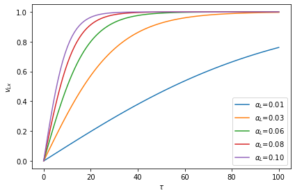

```python
from numpy import linspace,tanh

import matplotlib.pyplot as plt
fig=plt.figure()
ax=fig.gca()

for alfaL in linspace(1e-2,1e-1,5):
    taus=linspace(0,100,100)
    vLxs=tanh(alfaL*taus)
    ax.plot(taus,vLxs,label=fr"$\alpha_L$={alfaL:.2f}")

ax.legend()
ax.set_xlabel(fr"$\tau$");
ax.set_ylabel(fr"$v_{{Lx}}$");
fig.tight_layout()
```

**Figura 4.17.**

Lo que notamos es que independientemente del valor de la aceleración propia, la velocidad de la partícula nunca logra ser mayor que 1 (en unidades convencionales, la velocidad de la luz). Esto es consistente con los resultados obtenidos hasta ahora.

Habra una explicación física de por qué es así, ¿por qué, a pesar de la aceleración sostenida por la partícula, esta nunca logra llevarla a una velocidad mayor que la de la luz?

[figure not shown]

**Figura 4.18**. Cambios en la cuadrivelocidad y la cuadriaceleración

Una manera posible de explicarlo es apelando a la propiedad nueva de ortogonalidad entre la cuadrivelocidad y la cuadriaceleración. Lo que pasa cuando la velocidad aumenta es que la componente temporal de la cuadriaceleración va aumentando también:

$$ A^\mu_L : \gamma^4 (\vec{a}_L\cdot \vec{v}_L,\vec{a}_L) $$

Como resultado no solo la componente espacial de la cuadrivelocidad de la partícula se hace mayor, sino que también lo hace su componente temporal:

$$ U_L^\mu:\left(\gamma,\gamma\vec{v}_L\right) $$

Cuando la velocidad es próxima a la velocidad de la luz $v_L\rightarrow 1$, la cuadriaceleración tiene casi idénticas componentes temporal y espacial $A^\mu_L\rightarrow (\gamma^4 a_L, \gamma^4 a_L)$, esto implica que toda ganancia en la componente temporal de la cuadrivelocidad es igual a la ganancia en la componente espacial de la misma. De este modo, la cuadrivelocidad se mantiene cerca pero nunca igual a la correspondiente a la luz.

Otra manera de entenderlo es ver lo que pasa con la aceleración espacial $a_L$ cuando la velocidad va aumentando. En la configuración estándar y por la invarianza del módulo de la cuadriaceleración:

$$ \gamma^8(a_L^2v_L^2-a_L^2)=-\alpha_L^2 $$

de donde despejando $a_L$ queda:

$$ a_L=\frac{1}{\gamma^3}\alpha_L $$

es decir a medida que la velocidad va aumentando ($\gamma$ va creciendo) la aceleración medida por el observador se hace cada vez menor. Cuando el cuerpo se aproxima a la velocidad de la luz la aceleración espacial es casi nula y el cuerpo no gana ni un ápice más de velocidad.

### 4.11.5. Ejemplo: una nave interestelar

[figure not shown]

**Figura 4.19**. Nave interestelar

Uno de los más grandes sueños de exploración de la humanidad ha sido viajar a otras estrellas. Para hacerlo un diseño posible es el de construir una nave capaz de sostener una aceleración constante igual a la aceleración de la gravedad en la Tierra (para simular justamente los efectos de la gravedad), en unidades luz $\alpha_L=g/c$. ¿Cuánto le tomaría a una nave así, ir hasta Alpha Centauri situada en $x_L=4$ años-luz?

Para encontrar la solución a este problema basta que despejemos $\tau$ de la ecuación de la posición:

$$ \tau=\frac{1}{\alpha_L}\cosh^{-1}(\alpha_L x_L+1) $$

El manejo de las unidades aquí debe ser cuidadoso. Nótese que $[\alpha_L]=1/T_L$ y $[x_L]=T_L$, de modo que una vez se escogen las unidades de $\alpha_L$ quedan fijas las unidades de $x_L$.

$$ \alpha_L=\frac{g}{c}=\frac{9,8\;\mathrm{m}/\mathrm{s}^2}{3\times 10^8\;\mathrm{m/s}}=3.27\times 10^{-8}\;\mathrm{s^{-1}} $$

En este caso las unidades de $x_L$ deben ser segundos(-luz).

```python
#Velocidad de la luz
c=3e8 #m/s

#Aceleración
alphaL=9.8/3e8 #1/segundos-luz = 1 / s-l

#Distancia a recorrer
year=365.25*86400 # segundos
xL=4*year #s-l

#Tiempo propio
from numpy import arccosh
tau=arccosh(alphaL*xL+1)/alphaL #s

#Tiempo coordenado
from numpy import sinh
t=(1/alphaL)*sinh(alphaL*tau) #s

#Velocidad al llegar
from numpy import sinh
vL=tanh(alphaL*tau) # u.l.
```

```python
print(f"alpha_L = {alphaL} 1/s-l")
print(f"x_L = {xL} s-l")
print(f"alpha_L x_L = {alphaL*xL}")
print(f"tau = {tau} s = {tau/year} años")
print(f"t = {t} s = {t/year} años")
print(f"v_L = {vL} = {vL*c} m/s")
```

```
alpha_L = 3.266666666666667e-08 1/s-l
x_L = 126230400.0 s-l
alpha_L x_L = 4.1235264
tau = 70938597.2561709 s = 2.2479084992575764 años
t = 153826219.22447002 s = 4.874458742885074 años
v_L = 0.9807678219437598 = 294230346.5831279 m/s
```

Indice | Previo: RelatividadEspecial.CinematicaRelativista.Definiciones | Siguiente: RelatividadEspecial.DinamicaRelativista.EnergiaMomentum